# Effect of a New Inhaled Therapy on Lung Function in Mild Asthma

Author

Natallia Halai

Published

April 28, 2026

Abstract:

A randomized controlled trial evaluates a new inhaled corticosteroid (ICS-X) compared to a standard inhaler in patients with mild persistent asthma. Patients are randomized to receive either ICS-X or standard therapy for 6 weeks. Lung function is assessed at baseline and at follow-up using FEV₁ (forced expiratory volume in 1 second). The primary endpoint is improvement in FEV₁.

# 1 Hypothesis

- ICS-X leads to greater improvement in FEV₁
- Higher baseline FEV₁ is associated with less room for improvement
- Smokers exhibit a reduced treatment response
- A negative Age effect on improvement

# 2 Data Exploration

## 2.1 Numerically

```r
cor_baseline<-cor(lung_function$baseline_fev1, lung_function$fev1_improvement)
cor_age<-cor(lung_function$age, lung_function$fev1_improvement)

correlation_table<-data.frame(
  Variable_1=c("Baseline FEV", "Age"),
  Variable_2=c("FEV Improvement", "FEV Improvement"),
  Corr_value=c(cor_baseline, cor_age)
)

knitr::kable(correlation_table)
```

Table 1: Correlation values for continuous variables Age and Baseline FEV

| Variable_1 | Variable_2 | Corr_value |
| --- | --- | --- |
| Baseline FEV | FEV Improvement | -0.5043706 |
| Age | FEV Improvement | -0.2892998 |

As the first step in the data exploration correlation values were calculated for the 2 continuous variables Age and Baseline FEV as seen in Table 1 . Here we can partly confirm our hypotheses which state that Age has a negative effect on FEV improvement (corr: -0.2892998 ) as well as high Baseline FEV association with less FEV improvement (corr: -0.5043706).

## 2.2 Graphically

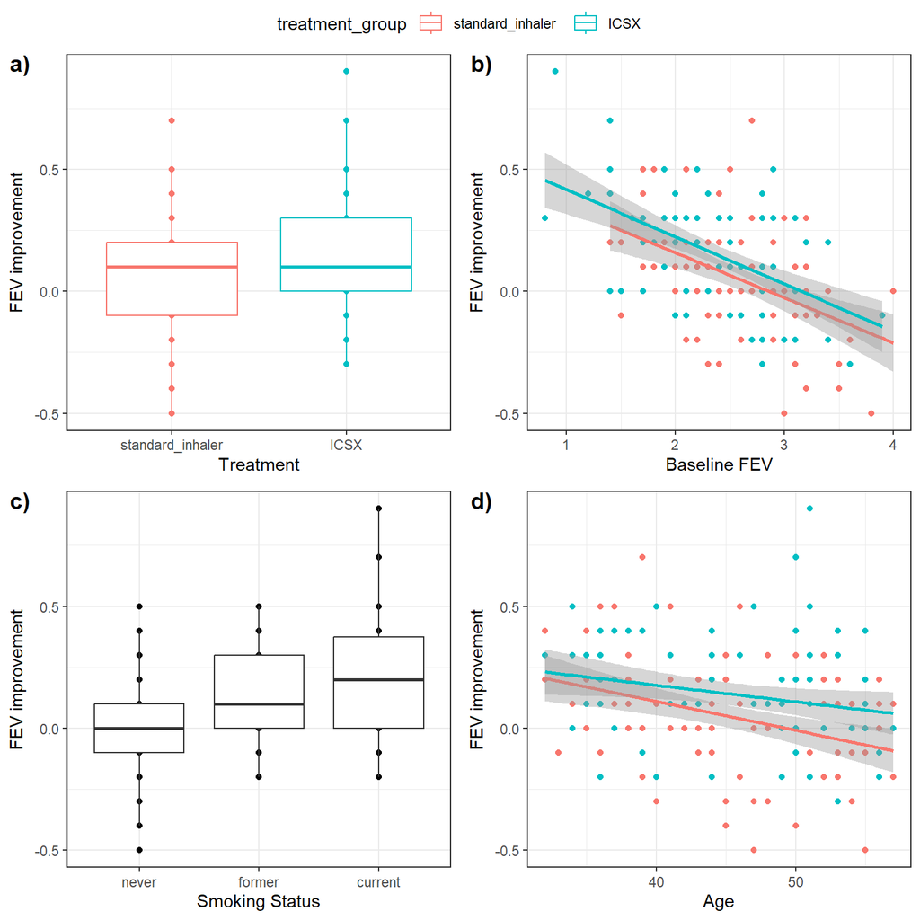

Figure 1

```r
ggarrange(
  ggplot(lung_function, aes(x=treatment_group, y=fev1_improvement, color=treatment_group))+
    geom_point()+
    geom_boxplot(outlier.shape = NA)+
    labs(x="Treatment", y="FEV improvement"),

  ggplot(lung_function, aes(x=baseline_fev1,y=fev1_improvement, color=treatment_group))+
    geom_point()+
    geom_smooth(method="lm")+
    labs(x="Baseline FEV", y="FEV improvement"),

  ggplot(lung_function, aes(x=smoking_status, y=fev1_improvement))+
    geom_point()+
    geom_boxplot(outlier.shape=NA)+
    labs(x="Smoking Status", y="FEV improvement"),

  ggplot(lung_function, aes(x=age, y=fev1_improvement, color=treatment_group))+
    geom_point()+
    geom_smooth(method="lm")+
    labs(x="Age", y="FEV improvement"),

  common.legend = TRUE, labels=c("a)", "b)", "c)", "d)")
)
```

In Figure 1 we can see different predictor variables plotted against FEV improvement response variable.